# Liver Disease Image Classifier

## Model Building

### Model 1 - CNN Model Building

```python
from tensorflow.keras.models import Sequential
from tensorflow.keras.layers import Conv2D, MaxPooling2D, Flatten, Dense, Dropout, BatchNormalization

cnn_model = Sequential()

cnn_model.add(Conv2D(64, (3, 3), activation='relu', input_shape=(128, 128, 3), padding='same'))
cnn_model.add(MaxPooling2D((2, 2)))
cnn_model.add(BatchNormalization())

cnn_model.add(Conv2D(32, (3, 3), activation='relu', padding='same'))
cnn_model.add(MaxPooling2D((2, 2)))
cnn_model.add(BatchNormalization())

cnn_model.add(Conv2D(32, (3, 3), activation='relu', padding='same'))
cnn_model.add(MaxPooling2D((2, 2)))
cnn_model.add(BatchNormalization())

cnn_model.add(Flatten())
cnn_model.add(Dense(128, activation='relu'))
cnn_model.add(Dropout(0.3))
cnn_model.add(Dense(64, activation='relu'))
cnn_model.add(Dropout(0.3))
cnn_model.add(Dense(21, activation='softmax'))  # 21 classes
```

- activation functios introduce non-linearity into the model
  - allowing to learn complex patterns and relationships in the data
  - types
    - ReLU (rectified Linear Unit)
    - Sigmoid: gives probability like logistic regression
    - tanh

```python
cnn_model.compile(
    loss='categorical_crossentropy',
    optimizer='adam',
    metrics=['accuracy']
)

cnn_model.summary()
```

```
Model: "sequential"
```

```
┏━━━━━━━━━━━━━━━━━━━━━━━━━━━━━━━━━━━━━━┳━━━━━━━━━━━━━━━━━━━━━━━━━━━━━┳━━━━━━━━━━━━━━━━━┓
┃ Layer (type)                         ┃ Output Shape                ┃         Param # ┃
┡━━━━━━━━━━━━━━━━━━━━━━━━━━━━━━━━━━━━━━╇━━━━━━━━━━━━━━━━━━━━━━━━━━━━━╇━━━━━━━━━━━━━━━━━┩
│ conv2d (Conv2D)                      │ (None, 128, 128, 64)        │           1,792 │
├──────────────────────────────────────┼─────────────────────────────┼─────────────────┤
│ max_pooling2d (MaxPooling2D)         │ (None, 64, 64, 64)          │               0 │
├──────────────────────────────────────┼─────────────────────────────┼─────────────────┤
│ batch_normalization                  │ (None, 64, 64, 64)          │             256 │
│ (BatchNormalization)                 │                             │                 │
├──────────────────────────────────────┼─────────────────────────────┼─────────────────┤
│ conv2d_1 (Conv2D)                    │ (None, 64, 64, 32)          │          18,464 │
├──────────────────────────────────────┼─────────────────────────────┼─────────────────┤
│ max_pooling2d_1 (MaxPooling2D)       │ (None, 32, 32, 32)          │               0 │
├──────────────────────────────────────┼─────────────────────────────┼─────────────────┤
│ batch_normalization_1                │ (None, 32, 32, 32)          │             128 │
│ (BatchNormalization)                 │                             │                 │
├──────────────────────────────────────┼─────────────────────────────┼─────────────────┤
│ conv2d_2 (Conv2D)                    │ (None, 32, 32, 32)          │           9,248 │
├──────────────────────────────────────┼─────────────────────────────┼─────────────────┤
│ max_pooling2d_2 (MaxPooling2D)       │ (None, 16, 16, 32)          │               0 │
├──────────────────────────────────────┼─────────────────────────────┼─────────────────┤
│ batch_normalization_2                │ (None, 16, 16, 32)          │             128 │
│ (BatchNormalization)                 │                             │                 │
├──────────────────────────────────────┼─────────────────────────────┼─────────────────┤
│ flatten (Flatten)                    │ (None, 8192)                │               0 │
├──────────────────────────────────────┼─────────────────────────────┼─────────────────┤
│ dense (Dense)                        │ (None, 128)                 │       1,048,704 │
├──────────────────────────────────────┼─────────────────────────────┼─────────────────┤
│ dropout (Dropout)                    │ (None, 128)                 │               0 │
├──────────────────────────────────────┼─────────────────────────────┼─────────────────┤
│ dense_1 (Dense)                      │ (None, 64)                  │           8,256 │
├──────────────────────────────────────┼─────────────────────────────┼─────────────────┤
│ dropout_1 (Dropout)                  │ (None, 64)                  │               0 │
├──────────────────────────────────────┼─────────────────────────────┼─────────────────┤
│ dense_2 (Dense)                      │ (None, 21)                  │           1,365 │
└──────────────────────────────────────┴─────────────────────────────┴─────────────────┘
```

```
 Total params: 1,088,341 (4.15 MB)
```

```
 Trainable params: 1,088,085 (4.15 MB)
```

```
 Non-trainable params: 256 (1.00 KB)
```

```python
model_history = cnn_model.fit(
    train_generator,
    validation_data=(testX, testY),
    epochs=3,
    steps_per_epoch=50  # ✅ keeps it under 5 mins
)
```

```
50/50 ━━━━━━━━━━━━━━━━━━━━ 209s 4s/step - accuracy: 0.3542 - loss: 2.7896 - val_accuracy: 0.0000e+00 - val_loss: 2.6456
50/50 ━━━━━━━━━━━━━━━━━━━━ 177s 4s/step - accuracy: 0.3903 - loss: 2.1176 - val_accuracy: 0.0625 - val_loss: 3.7006
50/50 ━━━━━━━━━━━━━━━━━━━━ 165s 3s/step - accuracy: 0.4843 - loss: 1.7959 - val_accuracy: 0.0625 - val_loss: 4.0315
```

```python
# Evaluating on the Test dataset
cnn_model.evaluate(validation_generator)
```

```
225/225 ━━━━━━━━━━━━━━━━━━━━ 712s 3s/step - accuracy: 0.0677 - loss: 3.9765
```

```
[3.929409980773926, 0.06750000268220901]
```

### Model - Transfer Learning: VGG 16

```python
from tensorflow.keras.applications import VGG16

vgg_model = VGG16(weights='imagenet', include_top=False, input_shape=(224, 224, 3))

for layer in vgg_model.layers:
    layer.trainable = False
```

```
Downloading data from https://storage.googleapis.com/tensorflow/keras-applications/vgg16/vgg16_weights_tf_dim_ordering_tf_kernels_notop.h5
58889256/58889256 ━━━━━━━━━━━━━━━━━━━━ 0s 0us/step
```

```python
for layer in vgg_model.layers:
    print(layer.name, layer.trainable)
```

```
input_layer_1 False
block1_conv1 False
block1_conv2 False
block1_pool False
block2_conv1 False
block2_conv2 False
block2_pool False
block3_conv1 False
block3_conv2 False
block3_conv3 False
block3_pool False
block4_conv1 False
block4_conv2 False
block4_conv3 False
block4_pool False
block5_conv1 False
block5_conv2 False
block5_conv3 False
block5_pool False
```

```python
from tensorflow.keras.models import Sequential
from tensorflow.keras.layers import GlobalAveragePooling2D, Dense, Dropout

model2 = Sequential()
model2.add(vgg_model)
model2.add(GlobalAveragePooling2D())
model2.add(Dense(64, activation='relu'))
model2.add(Dropout(0.3))
model2.add(Dense(32, activation='relu'))
model2.add(Dropout(0.3))
model2.add(Dense(21, activation='softmax'))
```

```python
model2.compile(
    optimizer='adam',
    loss='categorical_crossentropy',
    metrics=['accuracy']
)

model2.summary()
```

```
Model: "sequential_1"
```

```
┏━━━━━━━━━━━━━━━━━━━━━━━━━━━━━━━━━━━━━━┳━━━━━━━━━━━━━━━━━━━━━━━━━━━━━┳━━━━━━━━━━━━━━━━━┓
┃ Layer (type)                         ┃ Output Shape                ┃         Param # ┃
┡━━━━━━━━━━━━━━━━━━━━━━━━━━━━━━━━━━━━━━╇━━━━━━━━━━━━━━━━━━━━━━━━━━━━━╇━━━━━━━━━━━━━━━━━┩
│ vgg16 (Functional)                   │ (None, 7, 7, 512)           │      14,714,688 │
├──────────────────────────────────────┼─────────────────────────────┼─────────────────┤
│ global_average_pooling2d             │ (None, 512)                 │               0 │
│ (GlobalAveragePooling2D)             │                             │                 │
├──────────────────────────────────────┼─────────────────────────────┼─────────────────┤
│ dense_3 (Dense)                      │ (None, 64)                  │          32,832 │
├──────────────────────────────────────┼─────────────────────────────┼─────────────────┤
│ dropout_2 (Dropout)                  │ (None, 64)                  │               0 │
├──────────────────────────────────────┼─────────────────────────────┼─────────────────┤
│ dense_4 (Dense)                      │ (None, 32)                  │           2,080 │
├──────────────────────────────────────┼─────────────────────────────┼─────────────────┤
│ dropout_3 (Dropout)                  │ (None, 32)                  │               0 │
├──────────────────────────────────────┼─────────────────────────────┼─────────────────┤
│ dense_5 (Dense)                      │ (None, 21)                  │             693 │
└──────────────────────────────────────┴─────────────────────────────┴─────────────────┘
```

```
 Total params: 14,750,293 (56.27 MB)
```

```
 Trainable params: 35,605 (139.08 KB)
```

```
 Non-trainable params: 14,714,688 (56.13 MB)
```

```python
# Generators (224x224 for VGG16)
train_generator = train_datagen.flow_from_directory(
    directory=train_dir,
    target_size=(224, 224),  # changed from (128, 128)
    batch_size=16,           # reduced batch size
    class_mode='categorical',
    subset='training'
)

validation_generator = test_datagen.flow_from_directory(
    directory=test_dir,
    target_size=(224, 224),  # changed from (128, 128)
    batch_size=50,
    class_mode='categorical'
)

testX, testY = validation_generator.__getitem__(0)
```

```
Found 31761 images belonging to 21 classes.
Found 3600 images belonging to 21 classes.
```

```python
# ✅ Train model using generator to get val_accuracy
new_model_history = model2.fit(
    train_generator,
    validation_data=validation_generator,  # ✅ This enables val_accuracy tracking
    epochs=3,
    steps_per_epoch=20  # ⏱ Reduce steps to lower RAM/time
)
```

```
20/20 ━━━━━━━━━━━━━━━━━━━━ 2414s 126s/step - accuracy: 0.1320 - loss: 2.9648 - val_accuracy: 0.3925 - val_loss: 2.3651
20/20 ━━━━━━━━━━━━━━━━━━━━ 2399s 126s/step - accuracy: 0.3513 - loss: 2.5358 - val_accuracy: 0.3925 - val_loss: 2.1236
20/20 ━━━━━━━━━━━━━━━━━━━━ 2441s 128s/step - accuracy: 0.3690 - loss: 2.2677 - val_accuracy: 0.3925 - val_loss: 1.9673
```

```python
model2.evaluate(validation_generator)
```

```
72/72 ━━━━━━━━━━━━━━━━━━━━ 2201s 31s/step - accuracy: 0.4010 - loss: 1.9804
```

```
[1.9672616720199585, 0.39250001311302185]
```

```python
# Function to plot both accuracy and loss
def plot_history(history, title):
    epochs = range(len(history.history['accuracy']))

    plt.figure(figsize=(14, 5))

    # Accuracy plot
    plt.subplot(1, 2, 1)
    plt.plot(epochs, history.history['accuracy'], label='train_accuracy')
    plt.plot(epochs, history.history['val_accuracy'], label='val_accuracy')
    plt.title(f'{title} - Accuracy')
    plt.xlabel('Epoch #')
    plt.ylabel('Accuracy')
    plt.legend()

    # Loss plot
    plt.subplot(1, 2, 2)
    plt.plot(epochs, history.history['loss'], label='train_loss')
    plt.plot(epochs, history.history['val_loss'], label='val_loss')
    plt.title(f'{title} - Loss')
    plt.xlabel('Epoch #')
    plt.ylabel('Loss')
    plt.legend()

    plt.tight_layout()
    plt.show()
```

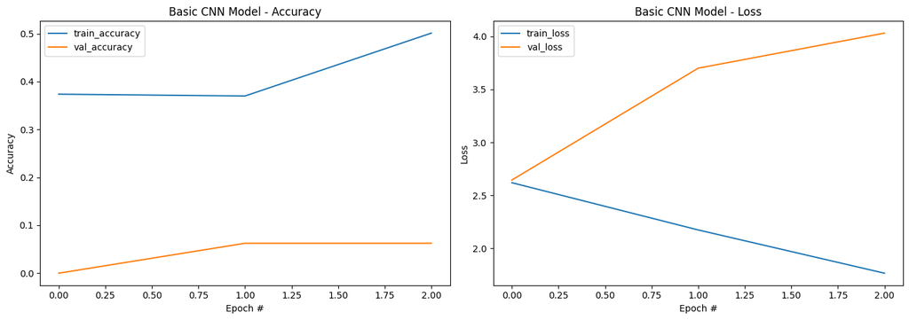

```python
# Plotting the curves for the basic CNN model
plot_history(model_history, "Basic CNN Model")
```

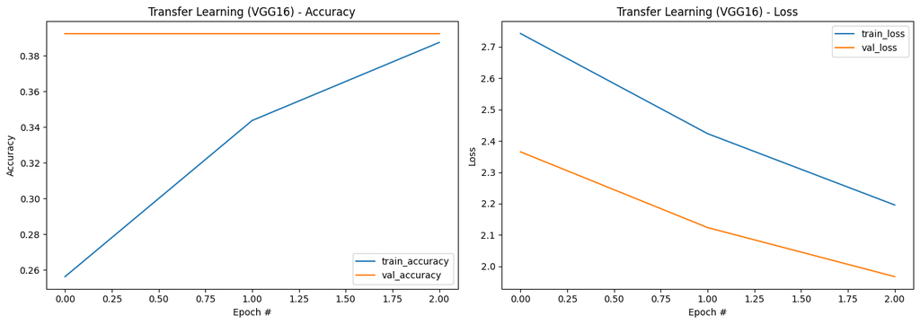

```python
# Plotting the curves for the VGG16 Transfer Learning model
plot_history(new_model_history, "Transfer Learning (VGG16)")
```

- Training & Validation Loss both decrease steadily — great sign of learning.
- Training Accuracy improves over epochs.
- Validation Accuracy stays flat (~0.39) — potential underfitting.

## Recommendations

- For this liver disease classification task:
  - Use transfer learning (VGG16 or better).
  - Fine-tune only dense layers to avoid overfitting and minimize resource usage.
- If needed, further boost performance with:
  - Class weighting or oversampling
  - Advanced augmentations
  - More efficient architectures (e.g., MobileNet for deployment)

```python
# # google

# path_ipynb = '/content/drive/MyDrive/My DS DA/Neural Networks (Deep Learning)/Image Classification/Liver Disease Deep learning image Classification.ipynb'
# notebook_path = path_ipynb

# !jupyter nbconvert --to html "{notebook_path}"

# from google.colab import files
# path_html = '/content/drive/MyDrive/My DS DA/Neural Networks (Deep Learning)/Image Classification/Liver Disease Deep learning image Classification.html'

# files.download(path_html)
```

[output not shown]